# Assesing differencies in the mis-splicing activity between the annotated introns from AD as compared to control samples

Sonia Garcia-Ruiz

17 November 2023

# 1 Background

To provide the reader with additional evidence supporting the patterns of splicing noise reported beyond the GTEx v8 dataset, we replicated the analyses include in this manuscript using an independent dataset of short-read RNA-sequencing. We analysed samples from fusiform gyrus of Alzheimer's (AD) and neurologically normal (control) post-mortem samples published on ["Diverse Brain Myeloid Expression Profiles Reveal Distinct Microglial Activation States and Aspects of Alzheimer's Disease Not Evident in Mouse Models"](https://doi.org/10.1016/j.celrep.2017.12.066). RNA was extracted from approximately 300 μg of frozen fusiform gyrus tissue blocks of autopsy-confirmed Alzheimer's cases and neurologically normal age-matched controls. Standard polyA-selected Illumina RNA-seq analysis was performed. Only samples with RNA integrity scores of at least 5 as well as post-mortem intervals lower than 5 hr were selected.

With this analysis, we aimed to evaluate whether there are any significant differences in the levels of MSR at the donor and acceptor splice sites of the annotated introns overlapping post-mortem samples diagnosed with Alzheimer's disease (AD) and neurologically normal (control) samples.

# 2 Methods

RNA-sequencing junction data corresponding to 98 samples was downloaded from recount3 (ID = "SRP100948") (Gene Expression Omnibus: GSE89482).

We classified these 98 samples by diagnosis in the "control" and "AD" groups, respectively. It is widely known that the presence of split reads within a sample can be affected by the sequencing depth of the sample. To reduce potential biases in any downstream comparison between the number of novel split reads found in AD versus control samples, we subsampled both sets of samples to match them by mapped read depth similarity, which reduced both datasets to 24 samples in each group (see Figure 2.1 below), and built a Splicing database following the methods indicated in this manuscript.

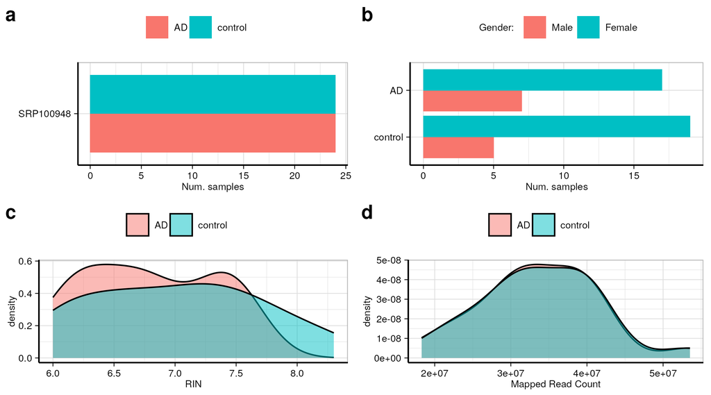

Figure 2.1: Metadata of the samples included in this analysis after downsampling them to match by read depth similarity.

To compare the level of mis-splicing activity of the annotated introns found across the 24 samples clustered within each sample group, we made use of their MSR values. To avoid potential biases due to differences in the expression levels of the introns studied in each group, we only considered those introns overlapping both groups and that displayed similar expression levels. Expression levels were measured by obtaining the cumulative number of split reads supporting the presence of each annotated intron across the samples of each group. The maximum difference of log10 mean expression levels allowed corresponded to 0.0005. This subsampling process reduced both distributions of introns to **144,479** in each sample group (see Figure 2.2 below).

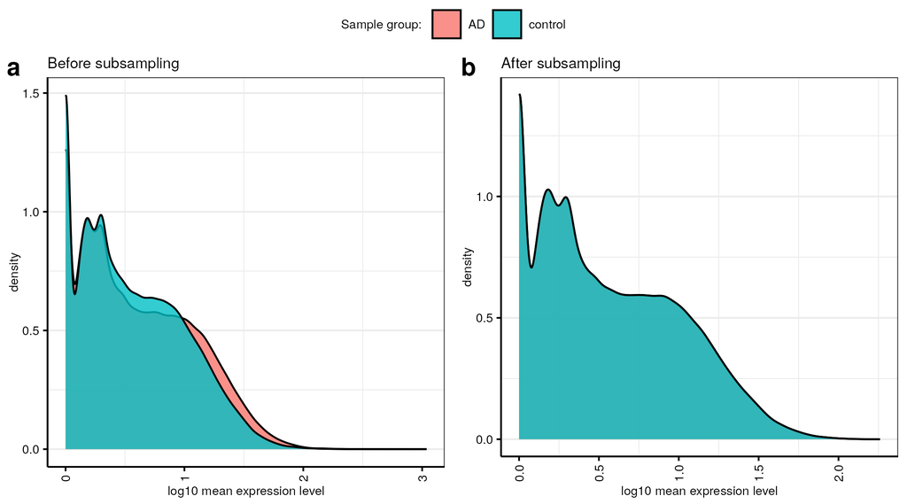

In all downstream statistical tests performed, we used one-tailed tests to evaluate differences in the distribution of MSR_D and MSR_A values between the common, subsampled introns from the AD and control group.

# 3 Results

Results from the comparison between the MSR values of the matched annotated introns between AD and control groups, showed that the common introns in the AD group presented significantly higher values of MSR at both their donor and acceptor splice sites compared to those matched introns across neurologically normal samples.

## 3.1 Unique number of novel junctions

We found a higher number of unique novel junctions in AD samples as compared to control samples.

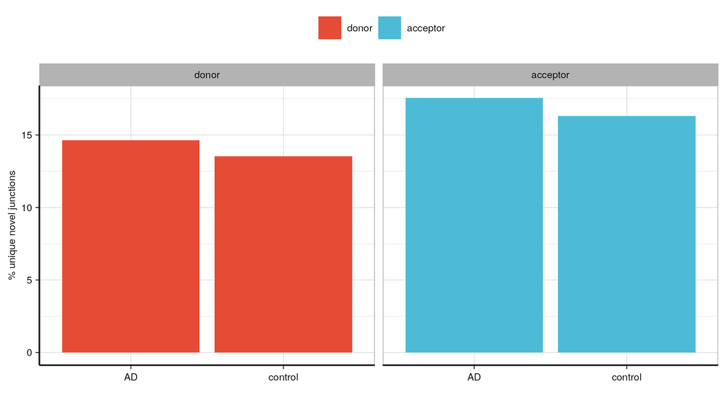

Figure 3.1: Unique novel donor and novel acceptor junctions in AD versus control samples.

## 3.2 Cummulative number of novel reads

We found that novel junctions in AD samples presented a higher cummulative number of supporting split reads as compared to control samples.

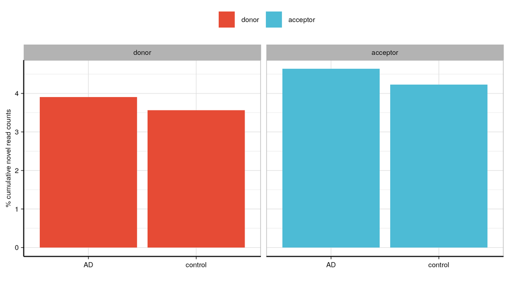

Figure 3.2: Cummulative number of supporting split reads that the novel donor and novel acceptor junctions present across the samples of the AD and control group, respectively.

## 3.3 Distances

We found that the annotated introns in AD samples presented a higher variety of novel junctions (as indicated by the y-axis) located in close proximity to annotated splice sites (represented by the x-axis position 0).

For interpretability purposes, only mis-splicing activity up to 30bp from annotated splice sites have been represented.

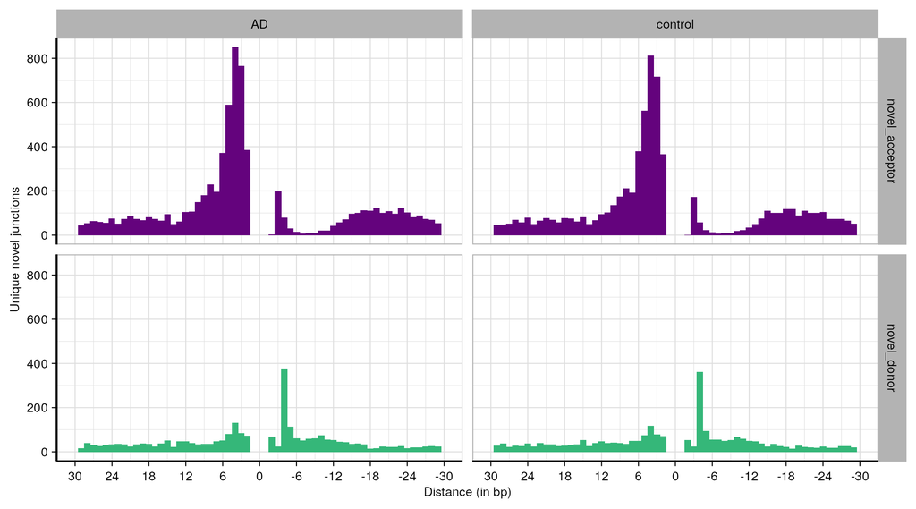

```r
file_path <- paste0(figures_path, '/distances.png')
knitr::include_graphics(file_path)
```

## 3.4 Modulo 3

Modulo3 of the distances. For this analysis, we only considered novel junctions from MANE transcripts and located within 100bp from annotated splice sites.

Results from this analysis indicated that, when compared to control samples, novel junctions in AD samples are more frequently located within distances **not divisible by 3**.

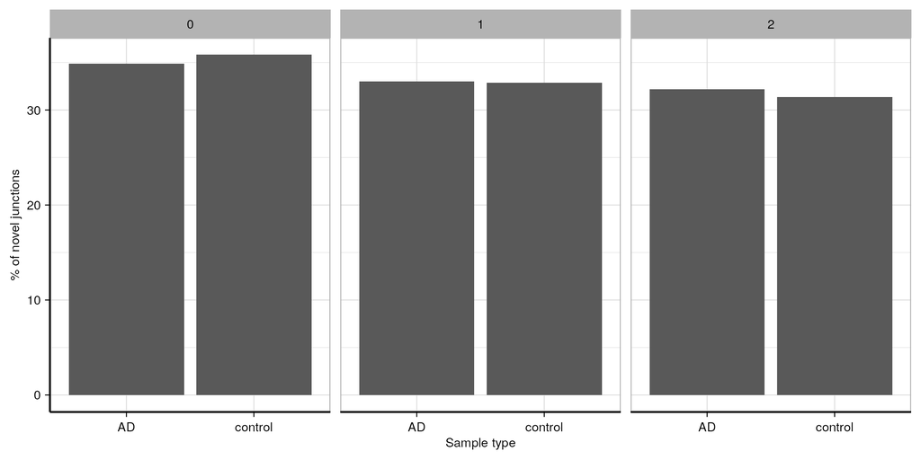

```r
file_path <- paste0(figures_path, '/modulo.png')
knitr::include_graphics(file_path)
```

## 3.5 MSR differences

### 3.5.1 MSR Donor

Considering the 144,479 annotated introns clustered within the AD group, below is the summary of their MSR at their donor splice site (i.e. the frequency of mis-splicing at their 5'ss):

```
##    Min. 1st Qu.  Median    Mean 3rd Qu.    Max.
## 0.00000 0.00000 0.00000 0.01388 0.00000 0.99576
```

Considering the same set of 144,479 annotated introns clustered within the control group, below is the summary of their MSR at their donor splice site:

```r
common_introns_subsample %>% filter(sample_type == "control") %>% pull(MSR_D) %>% summary
```

```
##     Min.  1st Qu.   Median     Mean  3rd Qu.     Max.
## 0.000000 0.000000 0.000000 0.009934 0.000000 0.987179
```

Introns from AD samples seem to present higher levels of mis-splicing activity at their donor splice site. To formally test this result, we performed a one-tailed paired Wilcoxon test. The alternative hypothesis tested corresponded to:

- **H1: the common annotated introns in AD samples have higher MSR at their donor splice sites than in control samples**

```
##
##  Wilcoxon signed rank test with continuity correction
##
## data:  common_introns_subsample %>% filter(sample_type == "AD") %>% pull(MSR_D) and common_introns_subsample %>% filter(sample_type == "control") %>% pull(MSR_D)
## V = 264019287, p-value < 2.2e-16
## alternative hypothesis: true location shift is greater than 0
```

Results from this one-tailed paired Wilcoxon test indicate that the null hypothesis is rejected and, therefore, the alternative hypothesis can be accepted.

### 3.5.2 MSR Acceptor

Considering the 144,479 annotated introns clustered within the AD group, below is the summary of their MSR at their acceptor splice site (i.e. the frequency of mis-splicing at their 3'ss):

```
##    Min. 1st Qu.  Median    Mean 3rd Qu.    Max.
## 0.00000 0.00000 0.00000 0.01549 0.00000 0.99715
```

Considering the same set of 144,479 annotated introns clustered within the control group, below is the summary of their MSR at their acceptor splice site:

```
##    Min. 1st Qu.  Median    Mean 3rd Qu.    Max.
## 0.00000 0.00000 0.00000 0.01116 0.00000 0.98723
```

Introns from AD samples seem to present higher levels of mis-splicing activity at their acceptor splice site. To formally test this result, we performed a one-tailed paired Wilcoxon test. The alternative hypothesis tested corresponded to:

- **H1: the common annotated introns in AD samples have higher MSR at their acceptor splice sites than in control samples**

```
##
##  Wilcoxon signed rank test with continuity correction
##
## data:  common_introns_subsample %>% filter(sample_type == "AD") %>% pull(MSR_A) and common_introns_subsample %>% filter(sample_type == "control") %>% pull(MSR_A)
## V = 307363171, p-value < 2.2e-16
## alternative hypothesis: true location shift is greater than 0
```

Results from this one-tailed paired Wilcoxon test indicate that the null hypothesis is rejected and, therefore, the alternative hypothesis can be accepted.

## 3.6 GO Enrichment

We run a GO Enrichment analysis of the genes that contained introns with increasing levels of mis-splicing activity at any of their two splice sites (i.e. MSR Donor and MSR Acceptor) in AD samples as compared to control samples.

### 3.6.1 Increasing MSR Donor

**Methods:** From the 144,469 annotated introns studied, we found that 12,289 introns presented higher levels of mis-splicing activity at their donor splice (i.e. MSR_D) site across AD samples as compared to control samples. There were n=7,428 unique genes parenting the 12,289 introns. As background, we used the 17,345 unique genes parenting all (n= 144,469) annotated introns studied. There were 11,887 introns with decreasing levels of MSR_D levels in AD vs control samples.

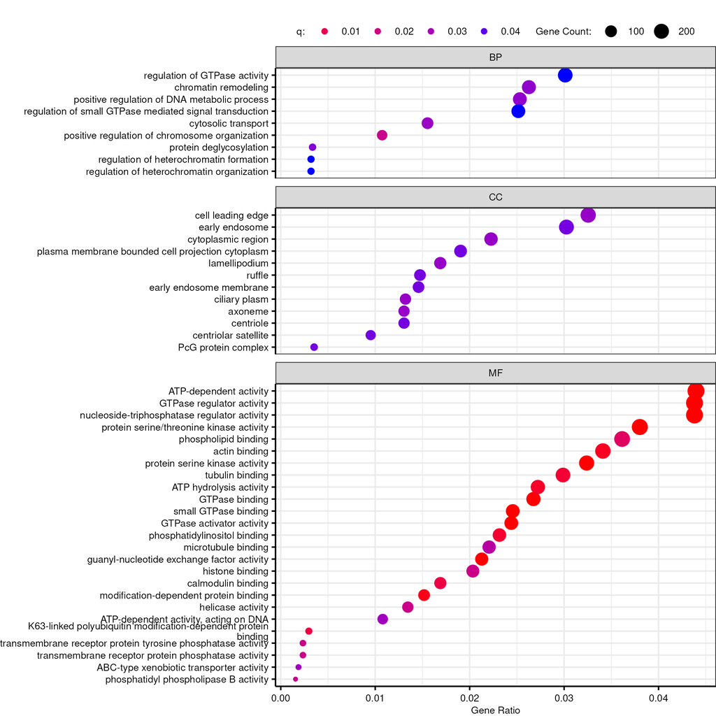

```r
file_path <- paste0(figures_path, '/go_enrichment_msrd.png')
knitr::include_graphics(file_path)
```

### 3.6.2 Increasing MSR Acceptor

**Methods:** From the 144,469 annotated introns studied, we found that 14,926 introns presented higher levels of mis-splicing activity at their acceptor splice (i.e. MSR_A) site across AD samples as compared to control samples. There were n=8,136 unique genes parenting the 14,926 introns. As background, we used the 17,345 unique genes parenting all (n= 144,469) annotated introns studied. There were 11,887 introns with decreasing levels of MSR_A levels in AD vs control samples.

[figure not shown]

```r
file_path <- paste0(figures_path, '/go_enrichment_msra.png')
knitr::include_graphics(file_path)
```

## 3.7 KEGG Enrichment

We run a KEGG Enrichment analysis of the genes that contained introns with increasing levels of mis-splicing activity at any of their two splice sites (i.e. MSR Donor and MSR Acceptor) in AD samples as compared to control samples.

### 3.7.1 Increasing MSR Donor

**Methods:** From the 144,469 annotated introns studied, we found that 12,289 introns presented higher levels of mis-splicing activity at their donor splice (i.e. MSR_D) site across AD samples as compared to control samples. There were n=7,428 unique genes parenting the 12,289 introns. As background, we used the 17,345 unique genes parenting all (n= 144,469) annotated introns studied. There were 11,887 introns with decreasing levels of MSR_D levels in AD vs control samples.

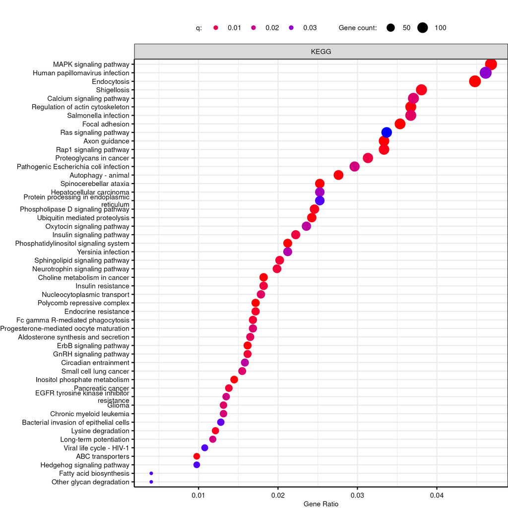

### 3.7.2 Increasing MSR Acceptor

**Methods:** From the 144,469 annotated introns studied, we found that 14,926 introns presented higher levels of mis-splicing activity at their acceptor splice (i.e. MSR_A) site across AD samples as compared to control samples. There were n=8,136 unique genes parenting the 14,926 introns. As background, we used the 17,345 unique genes parenting all (n= 144,469) annotated introns studied. There were 11,887 introns with decreasing levels of MSR_A levels in AD vs control samples.

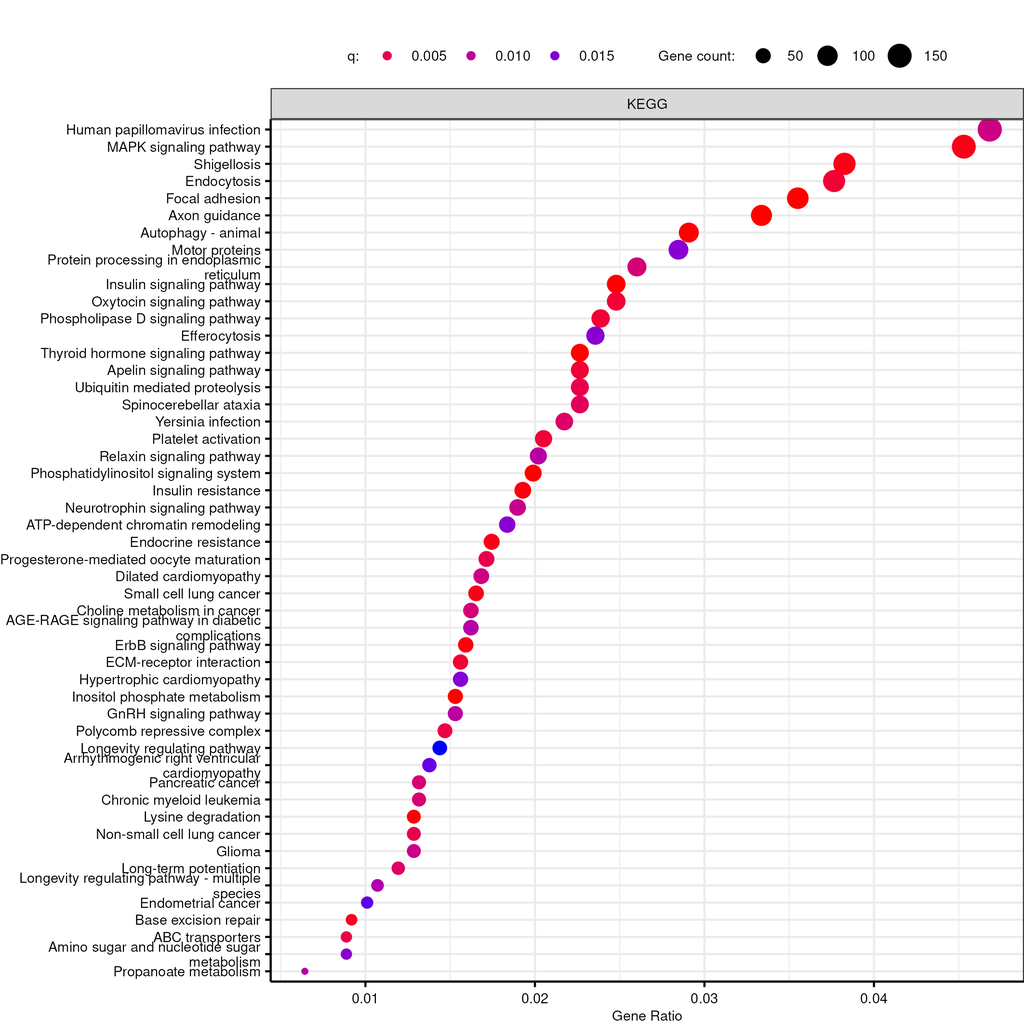

```r
file_path <- paste0(figures_path, '/kegg_enrichment_msra.png')
knitr::include_graphics(file_path)
```

# 4 Conclusions

**There is a significant increase in mis-splicing activity across introns in samples diagnosed with Alzheimer's disease (AD) as compared to introns across neurologically normal samples.**

**The patterns of splicing noise reported in the main manuscript robustly remain, regarding the MSR as a compelling measure to evaluate the mis-splicing activity of introns across different sample conditions.**

# 5 Session info

**Show/hide**